# Chapter 1

### Example 1.6 fMRI Imaging

fMRI data (brain imaging) from various brain locations on five subjects w/ periodic brushing of their hands. Response measures levels of activation in brain.

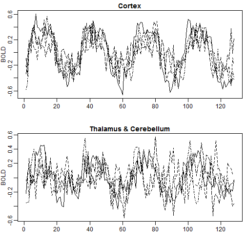

```r
par(mfrow = c(2, 1), # stack images
    mar = c(3, 2, 1, 0) + 0.5, # set margins
    mgp = c(1.6, .6, 0)) # margin line (closer titles)
ts.plot(fmri1[,2:5],
        lty = c(1:2, 4:5),
        ylab = "BOLD",
        xlab = "",
        main = "Cortex")
ts.plot(fmri1[,6:9],
        lty = c(1:2, 4:5),
        ylab = "BOLD",
        xlab = "",
        main = "Thalamus & Cerebellum")
```

Similar periods, but T&C has more variance & lower amplitude than Cortex. Both respond to the stimulus, but cortex responds more strongly.

### Example 1.7 Earthquakes & Explosions

Seismic data from the arrivals of waves from a recording station in Scandinavia.

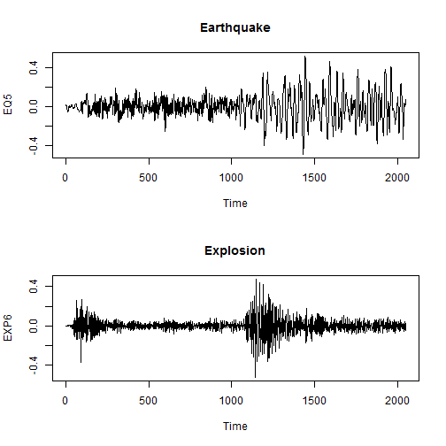

```r
par(mfrow = c(2, 1))
plot(EQ5, main = "Earthquake")
plot(EXP6, main = "Explosion")
```

Explosions start with a small burst, become small waves, then rapidly increase in amplitude before steadily diminishing.

Quakes start small, increase to a steady but moderately strong wave, then increase to large amplitude, but with a longer period. Waves decrease in strength slightly, then stay generally the same amplitude until the end of recording.

## Section 1.3 Time Series Statistical Models

- Need math/stat models that give plausible descriptions for time and frequency dependent data.
- Assume TS data is defined as a collection of RVs indexed according to time they are observed.
- Denotes \(\{x_t\}\) as vector of random variables indexed by \(t\) s.t. \(t = 0, \pm 1, \pm 2, \ldots\) or some subset of integers and values are observed for each time period, in order, and refer to a stochastic (random) process.
- The observed values of \(\{x_t\}\) are a realization of the stochastic process, and referred to as the time series.
- Generally we *can* observe the values at any continuous point in time and conceptually are dealing with continuous RVs. Because of restrictions in data collection, we are typically forced to use a discrete time parameter, however.
- Theoretical developments assume that continuous parameter time series should be specified in terms of finite-dimensional distribution functions defined over a *finite* number of points, allowing for a suitable definition of the periods indexed by \(t\).
- Insufficient sampling rates can lead to aliasing, discussed later.
- Generally we suppose that adjacent points in time are correlated, so \(x_t\) depends in some way on the values \(x_{t - 1}, x_{t - 2}, \ldots\)

## Example 1.8 White Noise

say we have uncorrelated random variables, \(w_t\) with mean 0 and variance \(\sigma^2_w\). The TS generated from uncorrelated variables is *white noise*. Denote white noise processes as \(w_t \sim wn(0, \sigma^2_w)\). This is analogous to white light, indicating that all possible period oscillations (waves) are present with equal strength.

When necessary, iid assumptions for \(w_t\) are represented as \(w_t \sim iid(0, \sigma^2_w)\)

If the stochastic behavior could simply be explained by white noise, we can use classical statistics because of the iid assumption. However, serial correlation and smoothness of TS data requires more sophisticated methods.

### Example 1.9 Moving Averages

Instead of a white noise series \(w_t\), we can replace it with a moving average that smooths the series. For example, replace the noise with an average of the current value and its immediate neighbors (both past & future).

\[ v_t = \frac{1}{3}\sum_{t = -1}^{1} w_t\]

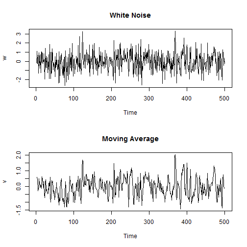

```r
w <- rnorm(500, 0, 1)
v <- filter(w, sides = 2, filter = rep(1/3, 3))
par(mfrow = c(2, 1))
plot.ts(w, main = "White Noise")
plot.ts(v, main = "Moving Average")
```

A linear combination of values in a TS are referred to as a filtered series, hence `filter`.

The speech series and Recruitment series differ from the moving average because one type of pattern in particular is predominant, generating a sinusoidal wave.

## Example 1.10 Autoregressions

Suppose \(w_t\) is simply an input to a second-order equation:

\[x_t = x_{t-1} - 0.9x_{t-2} + w_t\]

for \(t = 1, 2, \ldots, 500\). In this case, the equation represents a regression of the current value of \(x_t\) of the TS as a function of the past two values of the series, leading us to the term *autoregression*. Note that this leads to a problem with startup values, because the equation also depends on the initial conditions \(x_0\) and \(x_{-1}\). For now, assume we know these values.

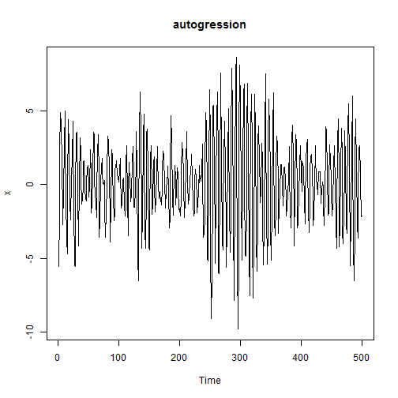

```r
w <- rnorm(550, 0, 1) #extra 50 to avoid startup issues
x <- filter(w, filter = c(1, -0.9), method = "recursive")[-(1:50)]
plot.ts(x, main = "autogression")
```

Autoregressive models are widely used for many observed TSs.

## Example 1.11 Random Walk with Drift

For trends like the global warming data, we often use a random walk with drift:

\[x_t = \delta + x_{t-1}+w_t\]

with initial condition \(x_0 = 0\), where \(w_t\) is white noise. \(\delta\) represents the drift, and \(\delta = 0\) denotes a random walk. We describe it as such because the value at time \(t\) is the value at time \(t-1\) plus some random movement determined by \(w_t\). This model can also be written as an expression of the cumulative sum of the white noise:

\[x_t = \delta t + \sum_{j = 1}^t w_j\]

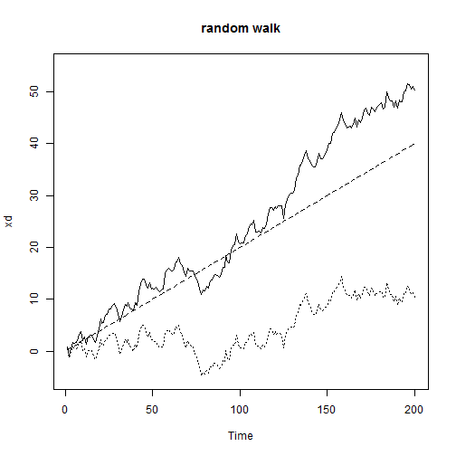

```r
set.seed(154)
## without drift
w <- rnorm(200, 0, 1)
x <- cumsum(w)
## with drift
wd <- w + .2
xd <- cumsum(wd)
plot.ts(xd, ylim = c(-5, 55), main = "random walk")
lines(x, lty = "dotted") ## no drift
lines(.2*(1:200), lty = "dashed") ## y = 0 + 0.2x
```